# PART - A

```python
import numpy as np
import pandas as pd
import matplotlib.pyplot as plt
import seaborn as sns
%matplotlib inline
import warnings
warnings.filterwarnings("ignore")
from sklearn.cluster import KMeans
from scipy.stats import stats
from scipy.stats import zscore
from sklearn.model_selection import train_test_split
from sklearn.preprocessing import StandardScaler
from sklearn import svm
from sklearn.svm import SVC
from sklearn.metrics import classification_report
from sklearn import metrics
from sklearn.decomposition import PCA
```

```python
# 1.1 a
```

```python
path = 'Part1+-+Car+name.csv'
data1 = pd.read_csv(path)
data1
```

|  | car_name |
| --- | --- |
| 0 | chevrolet chevelle malibu |
| 1 | buick skylark 320 |
| 2 | plymouth satellite |
| 3 | amc rebel sst |
| 4 | ford torino |
| ... | ... |
| 393 | ford mustang gl |
| 394 | vw pickup |
| 395 | dodge rampage |
| 396 | ford ranger |
| 397 | chevy s-10 |

398 rows × 1 columns

```python
# 1.1 b
```

```python
path = 'Part1+-+Car-Attributes.json'
data2 = pd.read_json(path)
data2
```

|  | mpg | cyl | disp | hp | wt | acc | yr | origin |
| --- | --- | --- | --- | --- | --- | --- | --- | --- |
| 0 | 18.0 | 8 | 307.0 | 130 | 3504 | 12.0 | 70 | 1 |
| 1 | 15.0 | 8 | 350.0 | 165 | 3693 | 11.5 | 70 | 1 |
| 2 | 18.0 | 8 | 318.0 | 150 | 3436 | 11.0 | 70 | 1 |
| 3 | 16.0 | 8 | 304.0 | 150 | 3433 | 12.0 | 70 | 1 |
| 4 | 17.0 | 8 | 302.0 | 140 | 3449 | 10.5 | 70 | 1 |
| ... | ... | ... | ... | ... | ... | ... | ... | ... |
| 393 | 27.0 | 4 | 140.0 | 86 | 2790 | 15.6 | 82 | 1 |
| 394 | 44.0 | 4 | 97.0 | 52 | 2130 | 24.6 | 82 | 2 |
| 395 | 32.0 | 4 | 135.0 | 84 | 2295 | 11.6 | 82 | 1 |
| 396 | 28.0 | 4 | 120.0 | 79 | 2625 | 18.6 | 82 | 1 |
| 397 | 31.0 | 4 | 119.0 | 82 | 2720 | 19.4 | 82 | 1 |

398 rows × 8 columns

```python
# 1.1 c
```

```python
data = pd.concat([data1, data2],axis = 1, join = 'outer', ignore_index=False, sort=False)
data
```

|  | car_name | mpg | cyl | disp | hp | wt | acc | yr | origin |
| --- | --- | --- | --- | --- | --- | --- | --- | --- | --- |
| 0 | chevrolet chevelle malibu | 18.0 | 8 | 307.0 | 130 | 3504 | 12.0 | 70 | 1 |
| 1 | buick skylark 320 | 15.0 | 8 | 350.0 | 165 | 3693 | 11.5 | 70 | 1 |
| 2 | plymouth satellite | 18.0 | 8 | 318.0 | 150 | 3436 | 11.0 | 70 | 1 |
| 3 | amc rebel sst | 16.0 | 8 | 304.0 | 150 | 3433 | 12.0 | 70 | 1 |
| 4 | ford torino | 17.0 | 8 | 302.0 | 140 | 3449 | 10.5 | 70 | 1 |
| ... | ... | ... | ... | ... | ... | ... | ... | ... | ... |
| 393 | ford mustang gl | 27.0 | 4 | 140.0 | 86 | 2790 | 15.6 | 82 | 1 |
| 394 | vw pickup | 44.0 | 4 | 97.0 | 52 | 2130 | 24.6 | 82 | 2 |
| 395 | dodge rampage | 32.0 | 4 | 135.0 | 84 | 2295 | 11.6 | 82 | 1 |
| 396 | ford ranger | 28.0 | 4 | 120.0 | 79 | 2625 | 18.6 | 82 | 1 |
| 397 | chevy s-10 | 31.0 | 4 | 119.0 | 82 | 2720 | 19.4 | 82 | 1 |

398 rows × 9 columns

```python
original_data = pd.concat([data1, data2],axis = 1, join = 'outer', ignore_index=False, sort=False)
```

```python
# 1.1 d
```

```python
data.describe().transpose()
```

|  | count | mean | std | min | 25% | 50% | 75% | max |
| --- | --- | --- | --- | --- | --- | --- | --- | --- |
| mpg | 398.0 | 23.514573 | 7.815984 | 9.0 | 17.500 | 23.0 | 29.000 | 46.6 |
| cyl | 398.0 | 5.454774 | 1.701004 | 3.0 | 4.000 | 4.0 | 8.000 | 8.0 |
| disp | 398.0 | 193.425879 | 104.269838 | 68.0 | 104.250 | 148.5 | 262.000 | 455.0 |
| wt | 398.0 | 2970.424623 | 846.841774 | 1613.0 | 2223.750 | 2803.5 | 3608.000 | 5140.0 |
| acc | 398.0 | 15.568090 | 2.757689 | 8.0 | 13.825 | 15.5 | 17.175 | 24.8 |
| yr | 398.0 | 76.010050 | 3.697627 | 70.0 | 73.000 | 76.0 | 79.000 | 82.0 |
| origin | 398.0 | 1.572864 | 0.802055 | 1.0 | 1.000 | 1.0 | 2.000 | 3.0 |

```python
# 1.2 a
```

```python
data.info()
```

```
<class 'pandas.core.frame.DataFrame'>
RangeIndex: 398 entries, 0 to 397
Data columns (total 9 columns):
 #   Column    Non-Null Count  Dtype
---  ------    --------------  -----
 0   car_name  398 non-null    object
 1   mpg       398 non-null    float64
 2   cyl       398 non-null    int64
 3   disp      398 non-null    float64
 4   hp        398 non-null    object
 5   wt        398 non-null    int64
 6   acc       398 non-null    float64
 7   yr        398 non-null    int64
 8   origin    398 non-null    int64
dtypes: float64(3), int64(4), object(2)
memory usage: 28.1+ KB
```

'hp' is represented as 'object' datatype though it has numerical values. Hence we need to check values present in it and also convert it into 'float' datatype.

```python
percent_missing = data.isnull().sum() * 100 / len(data)
percent_missing
```

```
car_name    0.0
mpg         0.0
cyl         0.0
disp        0.0
hp          0.0
wt          0.0
acc         0.0
yr          0.0
origin      0.0
dtype: float64
```

There were no missing values before we convert the 'hp' datatype and identifying unexpected values.

```python
data.hp.unique()
```

```
array([130, 165, 150, 140, 198, 220, 215, 225, 190, 170, 160, 95, 97, 85,
       88, 46, 87, 90, 113, 200, 210, 193, '?', 100, 105, 175, 153, 180,
       110, 72, 86, 70, 76, 65, 69, 60, 80, 54, 208, 155, 112, 92, 145,
       137, 158, 167, 94, 107, 230, 49, 75, 91, 122, 67, 83, 78, 52, 61,
       93, 148, 129, 96, 71, 98, 115, 53, 81, 79, 120, 152, 102, 108, 68,
       58, 149, 89, 63, 48, 66, 139, 103, 125, 133, 138, 135, 142, 77, 62,
       132, 84, 64, 74, 116, 82], dtype=object)
```

```python
# 1.2 h
```

Unexpected values like '?' are present in 'hp' column. First convert them into nan so that we can identify them as null values and can either impute or drop(if missing datapoints are less) them.

```python
data['hp'] = data['hp'].replace("?", np.nan)
```

```python
data['hp'].isnull().sum()
```

```
6
```

```python
percent_missing = data.isnull().sum() * 100 / len(data)
percent_missing
```

```
car_name    0.000000
mpg         0.000000
cyl         0.000000
disp        0.000000
hp          1.507538
wt          0.000000
acc         0.000000
yr          0.000000
origin      0.000000
dtype: float64
```

Only 6 missing values present and this is very negligable when compared to the size of entire dataset we can drop them.

```python
# Converting datatype of 'hp'
data['hp'] = data['hp'].astype('float64')
```

```python
data.info()
```

```
<class 'pandas.core.frame.DataFrame'>
RangeIndex: 398 entries, 0 to 397
Data columns (total 9 columns):
 #   Column    Non-Null Count  Dtype
---  ------    --------------  -----
 0   car_name  398 non-null    object
 1   mpg       398 non-null    float64
 2   cyl       398 non-null    int64
 3   disp      398 non-null    float64
 4   hp        392 non-null    float64
 5   wt        398 non-null    int64
 6   acc       398 non-null    float64
 7   yr        398 non-null    int64
 8   origin    398 non-null    int64
dtypes: float64(4), int64(4), object(1)
memory usage: 28.1+ KB
```

```python
data = data.dropna()
```

```python
percent_missing = data.isnull().sum() * 100 / len(data)
percent_missing
```

```
car_name    0.0
mpg         0.0
cyl         0.0
disp        0.0
hp          0.0
wt          0.0
acc         0.0
yr          0.0
origin      0.0
dtype: float64
```

Now, the data is clear of null values

```python
# 1.2 b
```

```python
data[data.duplicated()]
```

|  | car_name | mpg | cyl | disp | hp | wt | acc | yr | origin |
| --- | --- | --- | --- | --- | --- | --- | --- | --- | --- |

```python
data[data.duplicated()].sum()
```

```
car_name    0.0
mpg         0.0
cyl         0.0
disp        0.0
hp          0.0
wt          0.0
acc         0.0
yr          0.0
origin      0.0
dtype: float64
```

No duplicate values in data.

```python
# 1.2 c
```

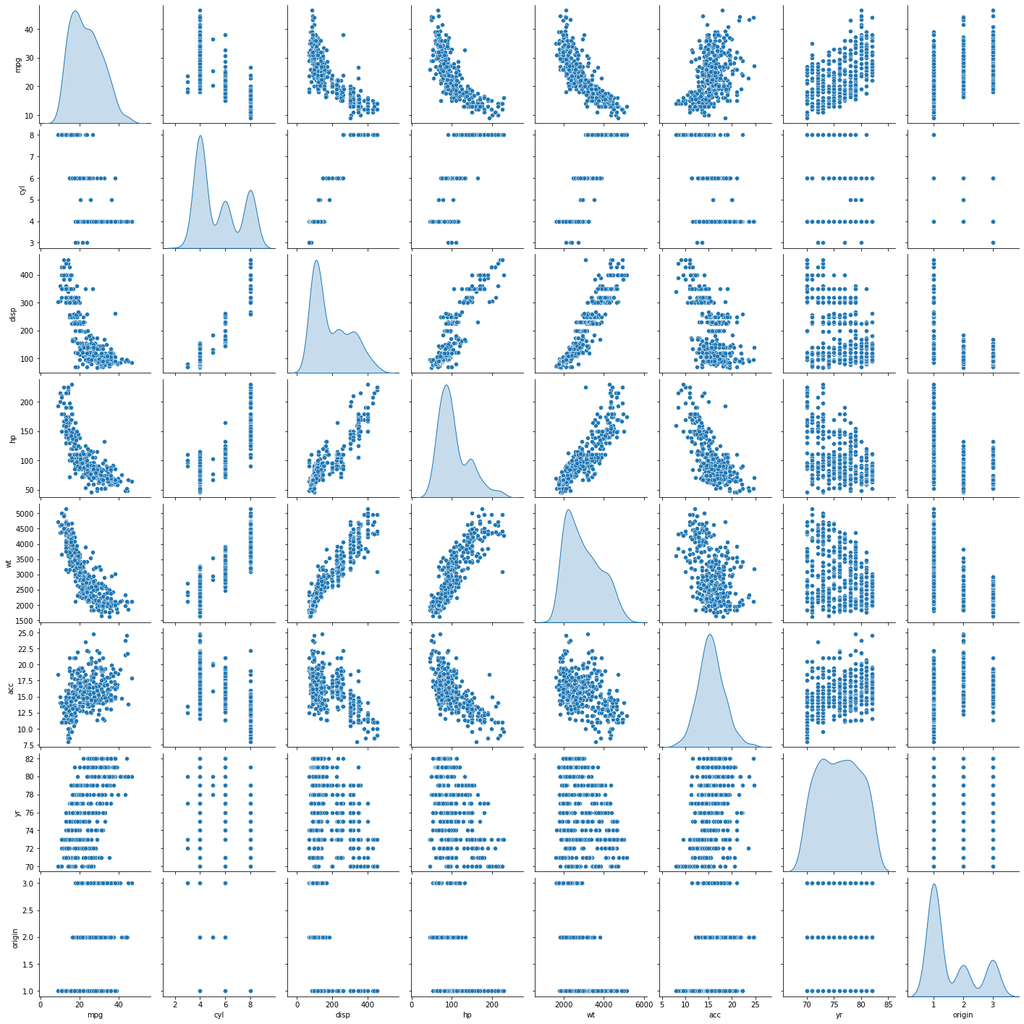

```python
sns.pairplot(data, diag_kind = 'kde');
```

```python
# 1.2 d
```

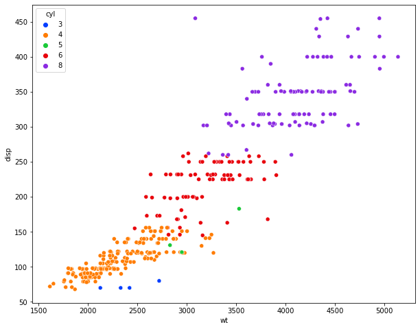

```python
fig, ax = plt.subplots(figsize=(10,8))
sns.scatterplot(data=data, x = 'wt', y = 'disp', hue= 'cyl', palette = 'bright');
```

```python
# 1.2 e
```

Insights :-

-'wt' and 'disp' are said to have positive correlation as displacement increases with increase in weight.

-Number of cylinders in a car increases with increase in 'wt' and 'disp'

-As weight increases number of cylinders in a car is also increased.

-Cars having 3 and 5 cylinders are very less in number and are present in the weight range(2000 to 3500).

-Cars having 8 cylinders have more wt followed by 6 and 4 cylinders respectively.

-8 cylinders are present in cars having more than 3000 wt and have displacement above 250.

```python
# 1.2 f
```

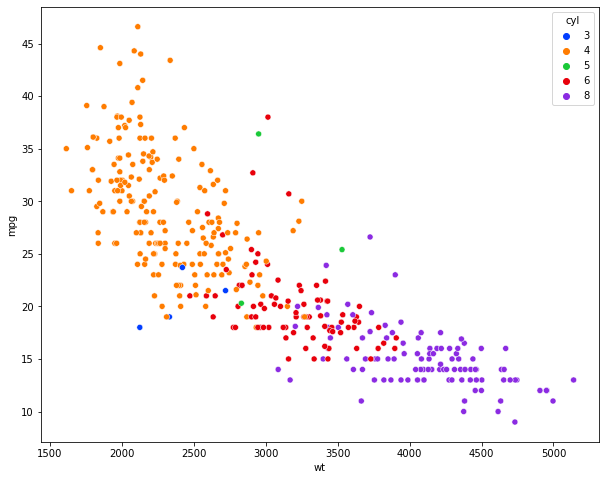

```python
fig, ax = plt.subplots(figsize=(10,8))
sns.scatterplot(data=data, x = 'wt', y = 'mpg', hue= 'cyl', palette = 'bright');
```

```python
# 1.2 g
```

Insights :-

-As 'wt' increases 'mpg' decreases and are said to have negative correlation.

-Number of cylinders are scattered instead of having a proper linear relation with 'wt' and 'mpg' graph.

-Cars having 4 cylinders have more miles per gallon and less weight when compared to others.

-Cars having 8 cylinders have more 'wt' and less 'mpg'.

-Cars having 6 cylinders are present in middle range instead of falling in either of extremes.

```python
# 1.2 h:- Done as a part of 1.2 a
```

```python
# 1.3 a
```

```python
data_attr = data.iloc[:,1:]
dataScaled = data_attr.apply(zscore)
```

```python
from scipy.spatial.distance import cdist
clusters=range(2,10)
meanDistortions=[]

for k in clusters:
    model=KMeans(n_clusters=k)
    model.fit(dataScaled)
    prediction=model.predict(dataScaled)
    meanDistortions.append(sum(np.min(cdist(dataScaled, model.cluster_centers_, 'euclidean'), axis=1)) / dataScaled.shape[0])
```

```python
# 1.3 b
```

```python
# Line plot
```

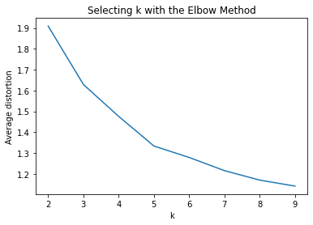

```python
plt.plot(clusters, meanDistortions)
plt.xlabel('k')
plt.ylabel('Average distortion')
plt.title('Selecting k with the Elbow Method')
plt.show()
```

```python
# Plot with elbow points
```

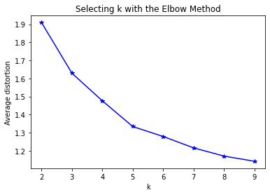

```python
plt.plot(clusters, meanDistortions, 'b*-')
plt.xlabel('k')
plt.ylabel('Average distortion')
plt.title('Selecting k with the Elbow Method')
plt.show()
```

Elbow point is at 5

```python
!pip install --upgrade kneed
```

```python
# 1.3 c
```

```
5
```

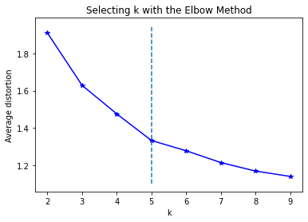

```python
from kneed import KneeLocator
kn = KneeLocator(clusters, meanDistortions, curve='convex', direction='decreasing')
print(kn.knee)
5
plt.plot(clusters, meanDistortions, 'b*-')
plt.xlabel('k')
plt.ylabel('Average distortion')
plt.title('Selecting k with the Elbow Method')
plt.vlines(kn.knee, plt.ylim()[0], plt.ylim()[1], linestyles='dashed')
plt.show()
```

```python
# 1.3 d
```

```python
# Let us first start with K = 5
final_model=KMeans(5)
final_model.fit(dataScaled)
prediction=final_model.predict(dataScaled)

#Append the prediction
data["cluster_value"] = prediction
dataScaled["cluster_value"] = prediction
print("cluster_value Assigned : \n")
data.head()
```

```
cluster_value Assigned :
```

|  | car_name | mpg | cyl | disp | hp | wt | acc | yr | origin | cluster_value |
| --- | --- | --- | --- | --- | --- | --- | --- | --- | --- | --- |
| 0 | chevrolet chevelle malibu | 18.0 | 8 | 307.0 | 130.0 | 3504 | 12.0 | 70 | 1 | 0 |
| 1 | buick skylark 320 | 15.0 | 8 | 350.0 | 165.0 | 3693 | 11.5 | 70 | 1 | 0 |
| 2 | plymouth satellite | 18.0 | 8 | 318.0 | 150.0 | 3436 | 11.0 | 70 | 1 | 0 |
| 3 | amc rebel sst | 16.0 | 8 | 304.0 | 150.0 | 3433 | 12.0 | 70 | 1 | 0 |
| 4 | ford torino | 17.0 | 8 | 302.0 | 140.0 | 3449 | 10.5 | 70 | 1 | 0 |

```python
dataSuppClust = data.groupby(['cluster_value'])
dataSuppClust.mean()
```

| cluster_value | mpg | cyl | disp | hp | wt | acc | yr | origin |
| --- | --- | --- | --- | --- | --- | --- | --- | --- |
| 0 | 14.429787 | 8.000000 | 350.042553 | 162.393617 | 4157.978723 | 12.576596 | 73.468085 | 1.000000 |
| 1 | 28.960000 | 4.200000 | 132.169231 | 82.538462 | 2551.307692 | 16.523077 | 79.630769 | 1.076923 |
| 2 | 34.035714 | 4.085714 | 99.728571 | 72.285714 | 2158.057143 | 16.740000 | 79.385714 | 2.785714 |
| 3 | 24.614458 | 4.048193 | 108.728916 | 85.578313 | 2351.253012 | 16.072289 | 73.337349 | 2.120482 |
| 4 | 19.081250 | 6.225000 | 233.862500 | 101.987500 | 3303.875000 | 16.627500 | 75.725000 | 1.037500 |

```python
# 1.3 e
```

```python
data['categories'] = prediction
```

```python
data
```

|  | car_name | mpg | cyl | disp | hp | wt | acc | yr | origin | cluster_value | categories |
| --- | --- | --- | --- | --- | --- | --- | --- | --- | --- | --- | --- |
| 0 | chevrolet chevelle malibu | 18.0 | 8 | 307.0 | 130.0 | 3504 | 12.0 | 70 | 1 | 0 | 0 |
| 1 | buick skylark 320 | 15.0 | 8 | 350.0 | 165.0 | 3693 | 11.5 | 70 | 1 | 0 | 0 |
| 2 | plymouth satellite | 18.0 | 8 | 318.0 | 150.0 | 3436 | 11.0 | 70 | 1 | 0 | 0 |
| 3 | amc rebel sst | 16.0 | 8 | 304.0 | 150.0 | 3433 | 12.0 | 70 | 1 | 0 | 0 |
| 4 | ford torino | 17.0 | 8 | 302.0 | 140.0 | 3449 | 10.5 | 70 | 1 | 0 | 0 |
| ... | ... | ... | ... | ... | ... | ... | ... | ... | ... | ... | ... |
| 393 | ford mustang gl | 27.0 | 4 | 140.0 | 86.0 | 2790 | 15.6 | 82 | 1 | 1 | 1 |
| 394 | vw pickup | 44.0 | 4 | 97.0 | 52.0 | 2130 | 24.6 | 82 | 2 | 2 | 2 |
| 395 | dodge rampage | 32.0 | 4 | 135.0 | 84.0 | 2295 | 11.6 | 82 | 1 | 1 | 1 |
| 396 | ford ranger | 28.0 | 4 | 120.0 | 79.0 | 2625 | 18.6 | 82 | 1 | 1 | 1 |
| 397 | chevy s-10 | 31.0 | 4 | 119.0 | 82.0 | 2720 | 19.4 | 82 | 1 | 1 | 1 |

392 rows × 11 columns

Newly added feature called categories in the DataFrame have labels based upon cluster value. Both newly added feature and cluster value have same labels.

```python
# 1.3 f
```

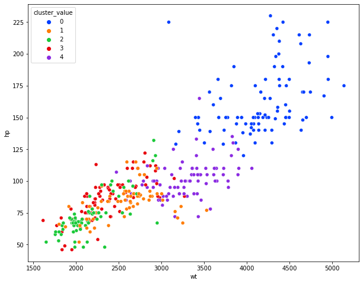

```python
fig, ax = plt.subplots(figsize=(10,8))
sns.scatterplot(data=data, x = 'wt', y = 'hp', hue= 'cluster_value', palette = 'bright');
```

0,1,2,3,4 are the labels or indices given to cluster_value.

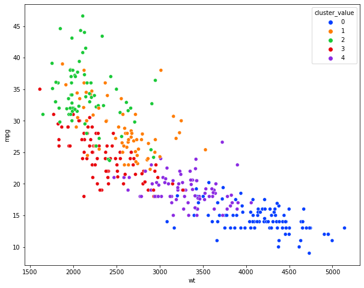

```python
fig, ax = plt.subplots(figsize=(10,8))
sns.scatterplot(data=data, x = 'wt', y = 'mpg', hue= 'cluster_value', palette = 'bright');
```

```python
# 1.3 g
```

Creating a new or synthetic row

```python
new_row = {'car_name': 'new_car', 'mpg' : 20.0, 'cyl' : 5, 'disp':320.0, 'hp':90.0, 'wt':3200 , 'acc' :15.0, 'yr' :82, 'origin':2}
```

Adding new row to original data

```python
new_data = original_data.append(new_row, ignore_index = True)
new_data
```

|  | car_name | mpg | cyl | disp | hp | wt | acc | yr | origin |
| --- | --- | --- | --- | --- | --- | --- | --- | --- | --- |
| 0 | chevrolet chevelle malibu | 18.0 | 8 | 307.0 | 130 | 3504 | 12.0 | 70 | 1 |
| 1 | buick skylark 320 | 15.0 | 8 | 350.0 | 165 | 3693 | 11.5 | 70 | 1 |
| 2 | plymouth satellite | 18.0 | 8 | 318.0 | 150 | 3436 | 11.0 | 70 | 1 |
| 3 | amc rebel sst | 16.0 | 8 | 304.0 | 150 | 3433 | 12.0 | 70 | 1 |
| 4 | ford torino | 17.0 | 8 | 302.0 | 140 | 3449 | 10.5 | 70 | 1 |
| ... | ... | ... | ... | ... | ... | ... | ... | ... | ... |
| 394 | vw pickup | 44.0 | 4 | 97.0 | 52 | 2130 | 24.6 | 82 | 2 |
| 395 | dodge rampage | 32.0 | 4 | 135.0 | 84 | 2295 | 11.6 | 82 | 1 |
| 396 | ford ranger | 28.0 | 4 | 120.0 | 79 | 2625 | 18.6 | 82 | 1 |
| 397 | chevy s-10 | 31.0 | 4 | 119.0 | 82 | 2720 | 19.4 | 82 | 1 |
| 398 | new_car | 20.0 | 5 | 320.0 | 90.0 | 3200 | 15.0 | 82 | 2 |

399 rows × 9 columns

Preprocessing appended row along with original data

```python
new_data['hp'] = new_data['hp'].replace("?", np.nan)
```

```python
new_data['hp'] = new_data['hp'].astype('float64')
```

```python
new_data = new_data.dropna()
```

```python
new_data_attr = new_data.iloc[:,1:]
new_dataScaled = new_data_attr.apply(zscore)
```

Predicting cluster to the new record

```python
final_model=KMeans(5)
final_model.fit(new_dataScaled)
prediction=final_model.predict(new_dataScaled)

new_data["cluster_value"] = prediction
new_dataScaled["cluster_value"] = prediction
print("cluster_value Assigned : \n")
new_data.tail()
```

```
cluster_value Assigned :
```

|  | car_name | mpg | cyl | disp | hp | wt | acc | yr | origin | cluster_value |
| --- | --- | --- | --- | --- | --- | --- | --- | --- | --- | --- |
| 394 | vw pickup | 44.0 | 4 | 97.0 | 52.0 | 2130 | 24.6 | 82 | 2 | 4 |
| 395 | dodge rampage | 32.0 | 4 | 135.0 | 84.0 | 2295 | 11.6 | 82 | 1 | 3 |
| 396 | ford ranger | 28.0 | 4 | 120.0 | 79.0 | 2625 | 18.6 | 82 | 1 | 3 |
| 397 | chevy s-10 | 31.0 | 4 | 119.0 | 82.0 | 2720 | 19.4 | 82 | 1 | 3 |
| 398 | new_car | 20.0 | 5 | 320.0 | 90.0 | 3200 | 15.0 | 82 | 2 | 1 |

Newly inserted row called new_car belongs to cluster_value = 1.

# PART B

```python
# 2.1 a
```

```python
path = 'vehicle.csv'
vehicle_df = pd.read_csv(path)
vehicle_df
```

|  | compactness | circularity | distance_circularity | radius_ratio | pr.axis_aspect_ratio | max.length_aspect_ratio | scatter_ratio | elongatedness | pr.axis_rectangularity | max.length_rectangularity | scaled_variance | scaled_variance.1 | scaled_radius_of_gyration | scaled_radius_of_gyration.1 | skewness_about | skewness_about.1 | skewness_about.2 | hollows_ratio | class |
| --- | --- | --- | --- | --- | --- | --- | --- | --- | --- | --- | --- | --- | --- | --- | --- | --- | --- | --- | --- |
| 0 | 95 | 48.0 | 83.0 | 178.0 | 72.0 | 10 | 162.0 | 42.0 | 20.0 | 159 | 176.0 | 379.0 | 184.0 | 70.0 | 6.0 | 16.0 | 187.0 | 197 | van |
| 1 | 91 | 41.0 | 84.0 | 141.0 | 57.0 | 9 | 149.0 | 45.0 | 19.0 | 143 | 170.0 | 330.0 | 158.0 | 72.0 | 9.0 | 14.0 | 189.0 | 199 | van |
| 2 | 104 | 50.0 | 106.0 | 209.0 | 66.0 | 10 | 207.0 | 32.0 | 23.0 | 158 | 223.0 | 635.0 | 220.0 | 73.0 | 14.0 | 9.0 | 188.0 | 196 | car |
| 3 | 93 | 41.0 | 82.0 | 159.0 | 63.0 | 9 | 144.0 | 46.0 | 19.0 | 143 | 160.0 | 309.0 | 127.0 | 63.0 | 6.0 | 10.0 | 199.0 | 207 | van |
| 4 | 85 | 44.0 | 70.0 | 205.0 | 103.0 | 52 | 149.0 | 45.0 | 19.0 | 144 | 241.0 | 325.0 | 188.0 | 127.0 | 9.0 | 11.0 | 180.0 | 183 | bus |
| ... | ... | ... | ... | ... | ... | ... | ... | ... | ... | ... | ... | ... | ... | ... | ... | ... | ... | ... | ... |
| 841 | 93 | 39.0 | 87.0 | 183.0 | 64.0 | 8 | 169.0 | 40.0 | 20.0 | 134 | 200.0 | 422.0 | 149.0 | 72.0 | 7.0 | 25.0 | 188.0 | 195 | car |
| 842 | 89 | 46.0 | 84.0 | 163.0 | 66.0 | 11 | 159.0 | 43.0 | 20.0 | 159 | 173.0 | 368.0 | 176.0 | 72.0 | 1.0 | 20.0 | 186.0 | 197 | van |
| 843 | 106 | 54.0 | 101.0 | 222.0 | 67.0 | 12 | 222.0 | 30.0 | 25.0 | 173 | 228.0 | 721.0 | 200.0 | 70.0 | 3.0 | 4.0 | 187.0 | 201 | car |
| 844 | 86 | 36.0 | 78.0 | 146.0 | 58.0 | 7 | 135.0 | 50.0 | 18.0 | 124 | 155.0 | 270.0 | 148.0 | 66.0 | 0.0 | 25.0 | 190.0 | 195 | car |
| 845 | 85 | 36.0 | 66.0 | 123.0 | 55.0 | 5 | 120.0 | 56.0 | 17.0 | 128 | 140.0 | 212.0 | 131.0 | 73.0 | 1.0 | 18.0 | 186.0 | 190 | van |

846 rows × 19 columns

```python
vehicle_df.info()
```

```
<class 'pandas.core.frame.DataFrame'>
RangeIndex: 846 entries, 0 to 845
Data columns (total 19 columns):
 #   Column                       Non-Null Count  Dtype
---  ------                       --------------  -----
 0   compactness                  846 non-null    int64
 1   circularity                  841 non-null    float64
 2   distance_circularity         842 non-null    float64
 3   radius_ratio                 840 non-null    float64
 4   pr.axis_aspect_ratio         844 non-null    float64
 5   max.length_aspect_ratio      846 non-null    int64
 6   scatter_ratio                845 non-null    float64
 7   elongatedness                845 non-null    float64
 8   pr.axis_rectangularity       843 non-null    float64
 9   max.length_rectangularity    846 non-null    int64
 10  scaled_variance              843 non-null    float64
 11  scaled_variance.1            844 non-null    float64
 12  scaled_radius_of_gyration    844 non-null    float64
 13  scaled_radius_of_gyration.1  842 non-null    float64
 14  skewness_about               840 non-null    float64
 15  skewness_about.1             845 non-null    float64
 16  skewness_about.2             845 non-null    float64
 17  hollows_ratio                846 non-null    int64
 18  class                        846 non-null    object
dtypes: float64(14), int64(4), object(1)
memory usage: 125.7+ KB
```

```python
vehicle_df.describe().T
```

|  | count | mean | std | min | 25% | 50% | 75% | max |
| --- | --- | --- | --- | --- | --- | --- | --- | --- |
| compactness | 846.0 | 93.678487 | 8.234474 | 73.0 | 87.00 | 93.0 | 100.0 | 119.0 |
| circularity | 841.0 | 44.828775 | 6.152172 | 33.0 | 40.00 | 44.0 | 49.0 | 59.0 |
| distance_circularity | 842.0 | 82.110451 | 15.778292 | 40.0 | 70.00 | 80.0 | 98.0 | 112.0 |
| radius_ratio | 840.0 | 168.888095 | 33.520198 | 104.0 | 141.00 | 167.0 | 195.0 | 333.0 |
| pr.axis_aspect_ratio | 844.0 | 61.678910 | 7.891463 | 47.0 | 57.00 | 61.0 | 65.0 | 138.0 |
| max.length_aspect_ratio | 846.0 | 8.567376 | 4.601217 | 2.0 | 7.00 | 8.0 | 10.0 | 55.0 |
| scatter_ratio | 845.0 | 168.901775 | 33.214848 | 112.0 | 147.00 | 157.0 | 198.0 | 265.0 |
| elongatedness | 845.0 | 40.933728 | 7.816186 | 26.0 | 33.00 | 43.0 | 46.0 | 61.0 |
| pr.axis_rectangularity | 843.0 | 20.582444 | 2.592933 | 17.0 | 19.00 | 20.0 | 23.0 | 29.0 |
| max.length_rectangularity | 846.0 | 147.998818 | 14.515652 | 118.0 | 137.00 | 146.0 | 159.0 | 188.0 |
| scaled_variance | 843.0 | 188.631079 | 31.411004 | 130.0 | 167.00 | 179.0 | 217.0 | 320.0 |
| scaled_variance.1 | 844.0 | 439.494076 | 176.666903 | 184.0 | 318.00 | 363.5 | 587.0 | 1018.0 |
| scaled_radius_of_gyration | 844.0 | 174.709716 | 32.584808 | 109.0 | 149.00 | 173.5 | 198.0 | 268.0 |
| scaled_radius_of_gyration.1 | 842.0 | 72.447743 | 7.486190 | 59.0 | 67.00 | 71.5 | 75.0 | 135.0 |
| skewness_about | 840.0 | 6.364286 | 4.920649 | 0.0 | 2.00 | 6.0 | 9.0 | 22.0 |
| skewness_about.1 | 845.0 | 12.602367 | 8.936081 | 0.0 | 5.00 | 11.0 | 19.0 | 41.0 |
| skewness_about.2 | 845.0 | 188.919527 | 6.155809 | 176.0 | 184.00 | 188.0 | 193.0 | 206.0 |
| hollows_ratio | 846.0 | 195.632388 | 7.438797 | 181.0 | 190.25 | 197.0 | 201.0 | 211.0 |

```python
vehicle_df.isna().sum()
```

```
compactness                    0
circularity                    5
distance_circularity           4
radius_ratio                   6
pr.axis_aspect_ratio           2
max.length_aspect_ratio        0
scatter_ratio                  1
elongatedness                  1
pr.axis_rectangularity         3
max.length_rectangularity      0
scaled_variance                3
scaled_variance.1              2
scaled_radius_of_gyration      2
scaled_radius_of_gyration.1    4
skewness_about                 6
skewness_about.1               1
skewness_about.2               1
hollows_ratio                  0
class                          0
dtype: int64
```

```python
# 2.1 b
```

```python
percent_missing = vehicle_df.isnull().sum() * 100 / len(vehicle_df)
percent_missing
```

```
compactness                    0.000000
circularity                    0.591017
distance_circularity           0.472813
radius_ratio                   0.709220
pr.axis_aspect_ratio           0.236407
max.length_aspect_ratio        0.000000
scatter_ratio                  0.118203
elongatedness                  0.118203
pr.axis_rectangularity         0.354610
max.length_rectangularity      0.000000
scaled_variance                0.354610
scaled_variance.1              0.236407
scaled_radius_of_gyration      0.236407
scaled_radius_of_gyration.1    0.472813
skewness_about                 0.709220
skewness_about.1               0.118203
skewness_about.2               0.118203
hollows_ratio                  0.000000
class                          0.000000
dtype: float64
```

Missing values were present in 14 columns. Except compactness, max.length_aspect_ratio, ma.length_rectangularity, hollows_ratio, class remaining all columns have missing values.

As missing values are present in different columns and rows, hence they were imputed with median instead of dropping.

Imputing missing values :-

```python
for i in vehicle_df.columns[:17]:
    median_value = vehicle_df[i].median()
    vehicle_df[i] = vehicle_df[i].fillna(median_value)
```

```python
vehicle_df.isna().sum()
```

```
compactness                    0
circularity                    0
distance_circularity           0
radius_ratio                   0
pr.axis_aspect_ratio           0
max.length_aspect_ratio        0
scatter_ratio                  0
elongatedness                  0
pr.axis_rectangularity         0
max.length_rectangularity      0
scaled_variance                0
scaled_variance.1              0
scaled_radius_of_gyration      0
scaled_radius_of_gyration.1    0
skewness_about                 0
skewness_about.1               0
skewness_about.2               0
hollows_ratio                  0
class                          0
dtype: int64
```

Missing values were imputed

```python
vehicle_df['class'].unique()
```

```
array(['van', 'car', 'bus'], dtype=object)
```

```python
# 2.1c
```

[figure not shown]

```python
data_size = vehicle_df['class'].value_counts()
colors = ['blue','orange','green']
labels = 'van', 'car','bus'
explode = (0.1, 0, 0)
plt.pie(data_size,explode=explode, labels=labels, colors=colors,
        autopct='%1.1f%%', shadow=True, startangle=90,)
plt.title('Percentage of different vehicles in dataset')
plt.show()
```

```python
# 2.1 d
```

```python
vehicle_df[vehicle_df.duplicated()]
```

|  | compactness | circularity | distance_circularity | radius_ratio | pr.axis_aspect_ratio | max.length_aspect_ratio | scatter_ratio | elongatedness | pr.axis_rectangularity | max.length_rectangularity | scaled_variance | scaled_variance.1 | scaled_radius_of_gyration | scaled_radius_of_gyration.1 | skewness_about | skewness_about.1 | skewness_about.2 | hollows_ratio | class |
| --- | --- | --- | --- | --- | --- | --- | --- | --- | --- | --- | --- | --- | --- | --- | --- | --- | --- | --- | --- |

```python
vehicle_df.duplicated().sum()
```

```
0
```

No duplicate rows in the given dataset

```python
# 2.2 a
```

```python
x=vehicle_df.iloc[:,0:18]
y = vehicle_df.iloc[:,18]
```

```python
x_train, x_test, y_train, y_test = train_test_split(x,y, test_size = 0.3, random_state = 10)
```

```python
# 2.2 b
```

```python
sc = StandardScaler()
x_train_sc = sc.fit_transform(x_train)
x_test_sc = sc.fit_transform(x_test)
```

```python
# 2.3 a
```

```python
clf = SVC()
clf.fit(x_train, y_train)
prediction = clf.predict(x_test)
```

```python
prediction = clf.predict(x_test)
```

```python
# 2.3 b
```

```python
# check the accuracy on the training data
print('Accuracy on Training data: ',clf.score(x_train, y_train))
# check the accuracy on the testing data
print('Accuracy on Testing data: ', clf.score(x_test , y_test))
#Calculate the recall value
print('Recall value: ',metrics.recall_score(y_test, prediction, average='macro'))
#Calculate the precision value
print('Precision value: ',metrics.precision_score(y_test, prediction, average='macro'))
print("Confusion Matrix:\n",metrics.confusion_matrix(prediction,y_test))
print("Classification Report:\n",metrics.classification_report(prediction, y_test))
```

```
Accuracy on Training data:  0.6858108108108109
Accuracy on Testing data:  0.6496062992125984
Recall value:  0.6178261291889267
Precision value:  0.6190530058177117
Confusion Matrix:
 [[33  4 19]
 [31 96  3]
 [ 7 25 36]]
Classification Report:
               precision    recall  f1-score   support

         bus       0.46      0.59      0.52        56
         car       0.77      0.74      0.75       130
         van       0.62      0.53      0.57        68

    accuracy                           0.65       254
   macro avg       0.62      0.62      0.61       254
weighted avg       0.66      0.65      0.65       254
```

```python
xscaled = x.apply(zscore)
xscaled.head()
```

|  | compactness | circularity | distance_circularity | radius_ratio | pr.axis_aspect_ratio | max.length_aspect_ratio | scatter_ratio | elongatedness | pr.axis_rectangularity | max.length_rectangularity | scaled_variance | scaled_variance.1 | scaled_radius_of_gyration | scaled_radius_of_gyration.1 | skewness_about | skewness_about.1 | skewness_about.2 | hollows_ratio |
| --- | --- | --- | --- | --- | --- | --- | --- | --- | --- | --- | --- | --- | --- | --- | --- | --- | --- | --- |
| 0 | 0.160580 | 0.518073 | 0.057177 | 0.273363 | 1.310398 | 0.311542 | -0.207598 | 0.136262 | -0.224342 | 0.758332 | -0.401920 | -0.341934 | 0.285705 | -0.327326 | -0.073812 | 0.380870 | -0.312012 | 0.183957 |
| 1 | -0.325470 | -0.623732 | 0.120741 | -0.835032 | -0.593753 | 0.094079 | -0.599423 | 0.520519 | -0.610886 | -0.344578 | -0.593357 | -0.619724 | -0.513630 | -0.059384 | 0.538390 | 0.156798 | 0.013265 | 0.452977 |
| 2 | 1.254193 | 0.844303 | 1.519141 | 1.202018 | 0.548738 | 0.311542 | 1.148719 | -1.144597 | 0.935290 | 0.689401 | 1.097671 | 1.109379 | 1.392477 | 0.074587 | 1.558727 | -0.403383 | -0.149374 | 0.049447 |
| 3 | -0.082445 | -0.623732 | -0.006386 | -0.295813 | 0.167907 | 0.094079 | -0.750125 | 0.648605 | -0.610886 | -0.344578 | -0.912419 | -0.738777 | -1.466683 | -1.265121 | -0.073812 | -0.291347 | 1.639649 | 1.529056 |
| 4 | -1.054545 | -0.134387 | -0.769150 | 1.082192 | 5.245643 | 9.444962 | -0.599423 | 0.520519 | -0.610886 | -0.275646 | 1.671982 | -0.648070 | 0.408680 | 7.309005 | 0.538390 | -0.179311 | -1.450481 | -1.699181 |

```python
cov_matrix = np.cov(xscaled, rowvar=False)
print(cov_matrix)
```

```
[[ 1.00118343  0.68569786  0.79086299  0.69055952  0.09164265  0.14842463
   0.81358214 -0.78968322  0.81465658  0.67694334  0.76297234  0.81497566
   0.58593517 -0.24988794  0.23635777  0.15720044  0.29889034  0.36598446]
 [ 0.68569786  1.00118343  0.79325751  0.6216467   0.15396023  0.25176438
   0.8489411  -0.82244387  0.84439802  0.96245572  0.79724837  0.83693508
   0.92691166  0.05200785  0.14436828 -0.01145212 -0.10455005  0.04640562]
 [ 0.79086299  0.79325751  1.00118343  0.76794246  0.15864319  0.26499957
   0.90614687 -0.9123854   0.89408198  0.77544391  0.86253904  0.88706577
   0.70660663 -0.22621115  0.1140589   0.26586088  0.14627113  0.33312625]
 [ 0.69055952  0.6216467   0.76794246  1.00118343  0.66423242  0.45058426
   0.73529816 -0.79041561  0.70922371  0.56962256  0.79435372  0.71928618
   0.53700678 -0.18061084  0.04877032  0.17394649  0.38266622  0.47186659]
 [ 0.09164265  0.15396023  0.15864319  0.66423242  1.00118343  0.64949139
   0.10385472 -0.18325156  0.07969786  0.1270594   0.27323306  0.08929427
   0.12211524  0.15313091 -0.05843967 -0.0320139   0.24016968  0.26804208]
 [ 0.14842463  0.25176438  0.26499957  0.45058426  0.64949139  1.00118343
   0.16638787 -0.18035326  0.16169312  0.30630475  0.31933428  0.1434227
   0.18996732  0.29608463  0.01561769  0.04347324 -0.02611148  0.14408905]
 [ 0.81358214  0.8489411   0.90614687  0.73529816  0.10385472  0.16638787
   1.00118343 -0.97275069  0.99092181  0.81004084  0.94978498  0.9941867
   0.80082111 -0.02757446  0.07454578  0.21267959  0.00563439  0.1189581 ]
 [-0.78968322 -0.82244387 -0.9123854  -0.79041561 -0.18325156 -0.18035326
  -0.97275069  1.00118343 -0.95011894 -0.77677186 -0.93748998 -0.95494487
  -0.76722075  0.10342428 -0.05266193 -0.18527244 -0.11526213 -0.2171615 ]
 [ 0.81465658  0.84439802  0.89408198  0.70922371  0.07969786  0.16169312
   0.99092181 -0.95011894  1.00118343  0.81189327  0.93533261  0.98938264
   0.79763248 -0.01551372  0.08386628  0.21495454 -0.01867064  0.09940372]
 [ 0.67694334  0.96245572  0.77544391  0.56962256  0.1270594   0.30630475
   0.81004084 -0.77677186  0.81189327  1.00118343  0.74586628  0.79555492
   0.86747579  0.04167099  0.13601231  0.00136727 -0.10407076  0.07686047]
 [ 0.76297234  0.79724837  0.86253904  0.79435372  0.27323306  0.31933428
   0.94978498 -0.93748998  0.93533261  0.74586628  1.00118343  0.94679667
   0.77983844  0.11321163  0.03677248  0.19446837  0.01423606  0.08579656]
 [ 0.81497566  0.83693508  0.88706577  0.71928618  0.08929427  0.1434227
   0.9941867  -0.95494487  0.98938264  0.79555492  0.94679667  1.00118343
   0.79595778 -0.01541878  0.07696823  0.20104818  0.00622636  0.10305714]
 [ 0.58593517  0.92691166  0.70660663  0.53700678  0.12211524  0.18996732
   0.80082111 -0.76722075  0.79763248  0.86747579  0.77983844  0.79595778
   1.00118343  0.19169941  0.16667971 -0.05621953 -0.22471583 -0.11814142]
 [-0.24988794  0.05200785 -0.22621115 -0.18061084  0.15313091  0.29608463
  -0.02757446  0.10342428 -0.01551372  0.04167099  0.11321163 -0.01541878
   0.19169941  1.00118343 -0.08846001 -0.12633227 -0.749751   -0.80307227]
 [ 0.23635777  0.14436828  0.1140589   0.04877032 -0.05843967  0.01561769
   0.07454578 -0.05266193  0.08386628  0.13601231  0.03677248  0.07696823
   0.16667971 -0.08846001  1.00118343 -0.03503155  0.1154338   0.09724079]
 [ 0.15720044 -0.01145212  0.26586088  0.17394649 -0.0320139   0.04347324
   0.21267959 -0.18527244  0.21495454  0.00136727  0.19446837  0.20104818
  -0.05621953 -0.12633227 -0.03503155  1.00118343  0.07740174  0.20523257]
 [ 0.29889034 -0.10455005  0.14627113  0.38266622  0.24016968 -0.02611148
   0.00563439 -0.11526213 -0.01867064 -0.10407076  0.01423606  0.00622636
  -0.22471583 -0.749751    0.1154338   0.07740174  1.00118343  0.89363767]
 [ 0.36598446  0.04640562  0.33312625  0.47186659  0.26804208  0.14408905
   0.1189581  -0.2171615   0.09940372  0.07686047  0.08579656  0.10305714
  -0.11814142 -0.80307227  0.09724079  0.20523257  0.89363767  1.00118343]]
```

```python
# 2.3 c
```

```python
pca = PCA(n_components = 10)
pca.fit(xscaled)
```

```
PCA(n_components=10)
```

```python
print(pca.explained_variance_)
```

```
[9.40460261 3.01492206 1.90352502 1.17993747 0.91726063 0.53999263
 0.35887012 0.22193246 0.1606086  0.09185722]
```

Eigen values and eigen vectors

```python
eigenvalues, eigenvectors = np.linalg.eig(cov_matrix)
print('Eigen Vectors \n%s', eigenvectors)
print('\n Eigen Values \n%s', eigenvalues)
```

```
Eigen Vectors
%s [[ 2.75283688e-01  1.26953763e-01 -1.19922479e-01  7.83843562e-02
   6.95178336e-02 -1.44875476e-01 -4.51862331e-01 -5.66136785e-01
  -4.84418105e-01 -2.60076393e-01  4.65342885e-02 -1.20344026e-02
  -1.56136836e-01 -1.00728764e-02 -6.00532537e-03  6.00485194e-02
  -6.50956666e-02 -9.67780251e-03]
 [ 2.93258469e-01 -1.25576727e-01 -2.48205467e-02  1.87337408e-01
  -8.50649539e-02  3.02731148e-01  2.49103387e-01 -1.79851809e-01
  -1.41569001e-02  9.80779086e-02  3.01323693e-03  2.13635088e-01
  -1.50116709e-02 -9.15939674e-03  7.38059396e-02 -4.26993118e-01
  -2.61244802e-01 -5.97862837e-01]
 [ 3.04609128e-01  7.29516436e-02 -5.60143254e-02 -7.12008427e-02
   4.06645651e-02  1.38405773e-01 -7.40350569e-02  4.34748988e-01
  -1.67572478e-01 -2.05031597e-01  7.06489498e-01 -3.46330345e-04
   2.37111452e-01  6.94599696e-03 -2.50791236e-02  1.46240270e-01
   7.82651714e-02 -1.57257142e-01]
 [ 2.67606877e-01  1.89634378e-01  2.75074211e-01 -4.26053415e-02
  -4.61473714e-02 -2.48136636e-01  1.76912814e-01  1.01998360e-01
  -2.30313563e-01 -4.77888949e-02 -1.07151583e-01  1.57049977e-01
   3.07818692e-02 -4.20156482e-02 -3.59880417e-02 -5.21374718e-01
   5.60792139e-01  1.66551725e-01]
 [ 8.05039890e-02  1.22174860e-01  6.42012966e-01  3.27257119e-02
  -4.05494487e-02 -2.36932611e-01  3.97876601e-01 -6.87147927e-02
  -2.77128307e-01  1.08075009e-01  3.85169721e-02 -1.10106595e-01
   3.92804479e-02  3.12698087e-02  1.25847434e-02  3.63120360e-01
  -3.22276873e-01 -6.36138719e-02]
 [ 9.72756855e-02 -1.07482875e-02  5.91801304e-01  3.14147277e-02
   2.13432566e-01  4.19330747e-01 -5.03413610e-01  1.61153097e-01
   1.48032250e-01 -1.18266345e-01 -2.62254132e-01  1.32935328e-01
  -3.72884301e-02 -9.99915816e-03 -2.84168792e-02  6.27796802e-02
   4.87809642e-02 -8.63169844e-02]
 [ 3.17092750e-01 -4.81181371e-02 -9.76283108e-02 -9.57485748e-02
  -1.54853055e-02 -1.16100153e-01 -6.49879382e-02  1.00688056e-01
   5.44574214e-02  1.65167200e-01 -1.70405800e-01 -9.55883216e-02
  -3.94638419e-02  8.40975659e-01 -2.49652703e-01  6.40502241e-02
   1.81839668e-02 -7.98693109e-02]
 [-3.14133155e-01 -1.27498515e-02  5.76484384e-02  8.22901952e-02
   7.68518712e-02  1.41840112e-01 -1.38112945e-02 -2.15497166e-01
  -1.56867362e-01 -1.51612333e-01 -5.76632611e-02 -1.22012715e-01
   8.10394855e-01  2.38188639e-01 -4.21478467e-02 -1.86946145e-01
```

[output cut: 43 more lines]

```
   5.17222779e-01  1.93956186e-02  1.20597635e-01  3.53723696e-01
   1.86595152e-01  4.34282436e-02  7.67874680e-03  2.31451048e-01
   1.90629960e-01 -1.82212045e-01]
 [ 7.41453913e-02  5.40354258e-01  3.95242743e-02  4.74890311e-02
  -2.98614819e-02  2.41222817e-01 -1.57237839e-02 -3.04186304e-02
   1.71506343e-01  6.41314778e-02  9.19597847e-02 -6.85618161e-01
  -1.42380007e-01 -6.47700819e-03  6.37681817e-03 -2.88502234e-01
  -1.20966490e-01  9.04014702e-02]]

 Eigen Values
%s [9.40460261e+00 3.01492206e+00 1.90352502e+00 1.17993747e+00
 9.17260633e-01 5.39992629e-01 3.58870118e-01 2.21932456e-01
 1.60608597e-01 9.18572234e-02 6.64994118e-02 4.66005994e-02
 3.57947189e-02 2.96445743e-03 1.00257898e-02 2.74120657e-02
 1.79166314e-02 2.05792871e-02]
```

```python
print('Eigenvalues in descending order: \n%s' %eigenvalues)
```

[output not shown]

```python
# 2.3 d
```

```
Cumulative Variance Explained [ 52.18603365  68.9158021   79.47844095  86.02590063  91.11576952
  94.11218252  96.10354875  97.33504945  98.22626473  98.73597943
  99.10498391  99.36357011  99.5621946   99.71430385  99.82849808
  99.92791726  99.98355026 100.        ]
```

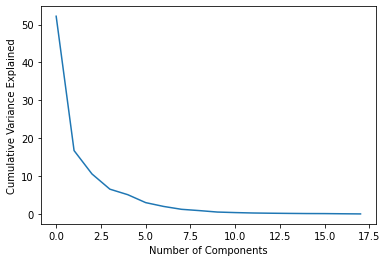

```python
tot = sum(eigenvalues)
var_exp = [( i /tot ) * 100 for i in sorted(eigenvalues, reverse=True)]
cum_var_exp = np.cumsum(var_exp)
print("Cumulative Variance Explained", cum_var_exp)
plt.ylabel('Cumulative Variance Explained')
plt.xlabel('Number of Components')
plt.plot(var_exp)
plt.show()
```

```python
# 2.3 e
```

[figure not shown]

```python
pca = pca.fit(xscaled)
xi = np.arange(1, 11, step=1)
y = np.cumsum(pca.explained_variance_)

plt.ylim(0.0,1.1)
plt.plot(xi, y, marker='o', linestyle='--', color='b')

plt.xlabel('Number of Components')
plt.xticks(np.arange(0, 11, step=1))
plt.ylabel('Cumulative Variance Explained')
plt.title('The number of components needed to explain variance')

plt.axhline(y=0.90, color='r', linestyle='-')
plt.text(0.5, 0.85, '90% cut-off threshold', color = 'red', fontsize=16)
plt.plot(var_exp)
plt.show()
```

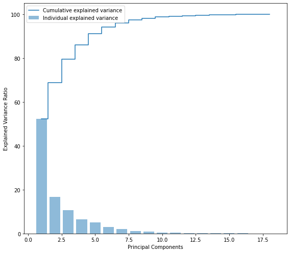

```python
plt.figure(figsize=(8 , 7))
plt.bar(range(1, eigenvalues.size + 1), var_exp, alpha = 0.5, align = 'center', label = 'Individual explained variance')
plt.step(range(1, eigenvalues.size + 1), cum_var_exp, where='mid', label = 'Cumulative explained variance')
plt.ylabel('Explained Variance Ratio')
plt.xlabel('Principal Components')
plt.legend(loc = 'best')
plt.tight_layout()
plt.show()
```

```python
# 2.3 f
```

```python
pca8 = PCA(n_components=8)
pca8.fit(xscaled)
print(pca8.components_)
print(pca8.explained_variance_)
xpca8 = pca8.transform(xscaled)
```

```
[[ 2.75283688e-01  2.93258469e-01  3.04609128e-01  2.67606877e-01
   8.05039890e-02  9.72756855e-02  3.17092750e-01 -3.14133155e-01
   3.13959064e-01  2.82830900e-01  3.09280359e-01  3.13788457e-01
   2.72047492e-01 -2.08137692e-02  4.14555082e-02  5.82250207e-02
   3.02795063e-02  7.41453913e-02]
 [-1.26953763e-01  1.25576727e-01 -7.29516436e-02 -1.89634378e-01
  -1.22174860e-01  1.07482875e-02  4.81181371e-02  1.27498515e-02
   5.99352482e-02  1.16220532e-01  6.22806229e-02  5.37843596e-02
   2.09233172e-01  4.88525148e-01 -5.50899716e-02 -1.24085090e-01
  -5.40914775e-01 -5.40354258e-01]
 [-1.19922479e-01 -2.48205467e-02 -5.60143254e-02  2.75074211e-01
   6.42012966e-01  5.91801304e-01 -9.76283108e-02  5.76484384e-02
  -1.09512416e-01 -1.70641987e-02  5.63239801e-02 -1.08840729e-01
  -3.14636493e-02  2.86277015e-01 -1.15679354e-01 -7.52828901e-02
   8.73592034e-03  3.95242743e-02]
 [ 7.83843562e-02  1.87337408e-01 -7.12008427e-02 -4.26053415e-02
   3.27257119e-02  3.14147277e-02 -9.57485748e-02  8.22901952e-02
  -9.24582989e-02  1.88005612e-01 -1.19844008e-01 -9.17449325e-02
   2.00095228e-01 -6.55051354e-02  6.04794251e-01 -6.66114117e-01
   1.05526253e-01  4.74890311e-02]
 [ 6.95178336e-02 -8.50649539e-02  4.06645651e-02 -4.61473714e-02
  -4.05494487e-02  2.13432566e-01 -1.54853055e-02  7.68518712e-02
   2.17633157e-03 -6.06366845e-02 -4.56472367e-04 -1.95548315e-02
  -6.15991681e-02  1.45530146e-01  7.29189842e-01  5.99196401e-01
  -1.00602332e-01 -2.98614819e-02]
 [ 1.44875476e-01 -3.02731148e-01 -1.38405773e-01  2.48136636e-01
   2.36932611e-01 -4.19330747e-01  1.16100153e-01 -1.41840112e-01
   9.80561329e-02 -4.61674972e-01  2.36225434e-01  1.57820194e-01
  -1.35576278e-01  2.41356821e-01  2.03209257e-01 -1.91960802e-01
   1.56939174e-01 -2.41222817e-01]
 [ 4.51862331e-01 -2.49103387e-01  7.40350569e-02 -1.76912814e-01
  -3.97876601e-01  5.03413610e-01  6.49879382e-02  1.38112945e-02
   9.66573058e-02 -1.04552173e-01  1.14622578e-01  8.37350220e-02
  -3.73944382e-01  1.11952983e-01 -8.06328902e-02 -2.84558723e-01
   1.81451818e-02  1.57237839e-02]
 [-5.66136785e-01 -1.79851809e-01  4.34748988e-01  1.01998360e-01
  -6.87147927e-02  1.61153097e-01  1.00688056e-01 -2.15497166e-01
   6.35933915e-02 -2.49495867e-01  5.02096319e-02  4.37649907e-02
  -1.08474496e-01 -3.40878491e-01  1.56487670e-01 -2.08774083e-01
  -3.04580219e-01 -3.04186304e-02]]
[9.40460261 3.01492206 1.90352502 1.17993747 0.91726063 0.53999263
 0.35887012 0.22193246]
```

Splitting data based on number of principal components selected from the above steps

```python
P_reduce = np.array(eigenvectors[0:8]).transpose()

Proj_train_data = np.dot(x_train_sc,P_reduce)

Proj_test_data = np.dot(x_test_sc,P_reduce)
```

```python
Proj_train_data.shape,y_train.shape,Proj_test_data.shape,y_test.shape
```

```
((592, 8), (592,), (254, 8), (254,))
```

```python
# 2.3 g
```

```python
from sklearn.svm import SVC

# Building a Support Vector Machine on train data
svc_model = SVC(C= .1, kernel='linear', gamma= 1)
svc_model.fit(Proj_train_data, y_train)

prediction = svc_model.predict(Proj_test_data)
```

```python
# 2.3 h
```

```python
print(svc_model.score(Proj_train_data, y_train))
print(svc_model.score(Proj_test_data, y_test))
```

```
0.8108108108108109
0.8385826771653543
```

```python
print('Recall value: ',metrics.recall_score(y_test, prediction, average='macro'))
#Calculate the precision value
print('Precision value: ',metrics.precision_score(y_test, prediction, average='macro'))
print("Confusion Matrix:\n",metrics.confusion_matrix(prediction,y_test))
print("Classification Report:\n",metrics.classification_report(prediction,y_test))
```

```
Recall value:  0.8284636554961956
Precision value:  0.8201494583847525
Confusion Matrix:
 [[ 54   5   6]
 [  8 110   3]
 [  9  10  49]]
Classification Report:
               precision    recall  f1-score   support

         bus       0.76      0.83      0.79        65
         car       0.88      0.91      0.89       121
         van       0.84      0.72      0.78        68

    accuracy                           0.84       254
   macro avg       0.83      0.82      0.82       254
weighted avg       0.84      0.84      0.84       254
```

Performance is better than before but we need to tune parameters in order to get a good score.

```python
# 2.4 a
```

```python
# Training another svm
svc_model = SVC(kernel='rbf')
svc_model.fit(Proj_train_data, y_train)

prediction = svc_model.predict(Proj_test_data)
```

```python
from sklearn.model_selection import GridSearchCV

# defining parameter range
param_grid = {'C': [0.1,0.5, 1],
              'gamma': [1, 0.1],
              'kernel': ['linear', 'rbf']}

grid = GridSearchCV(SVC(), param_grid, refit = True, verbose = 3)

# fitting the model for grid search
grid.fit(Proj_train_data, y_train)
```

```
Fitting 5 folds for each of 12 candidates, totalling 60 fits
[CV 1/5] END .....C=0.1, gamma=1, kernel=linear;, score=0.807 total time=   0.0s
[CV 2/5] END .....C=0.1, gamma=1, kernel=linear;, score=0.731 total time=   0.0s
[CV 3/5] END .....C=0.1, gamma=1, kernel=linear;, score=0.805 total time=   0.0s
[CV 4/5] END .....C=0.1, gamma=1, kernel=linear;, score=0.839 total time=   0.0s
[CV 5/5] END .....C=0.1, gamma=1, kernel=linear;, score=0.746 total time=   0.0s
[CV 1/5] END ........C=0.1, gamma=1, kernel=rbf;, score=0.580 total time=   0.0s
[CV 2/5] END ........C=0.1, gamma=1, kernel=rbf;, score=0.605 total time=   0.0s
[CV 3/5] END ........C=0.1, gamma=1, kernel=rbf;, score=0.602 total time=   0.0s
[CV 4/5] END ........C=0.1, gamma=1, kernel=rbf;, score=0.551 total time=   0.0s
[CV 5/5] END ........C=0.1, gamma=1, kernel=rbf;, score=0.551 total time=   0.0s
[CV 1/5] END ...C=0.1, gamma=0.1, kernel=linear;, score=0.807 total time=   0.0s
[CV 2/5] END ...C=0.1, gamma=0.1, kernel=linear;, score=0.731 total time=   0.0s
[CV 3/5] END ...C=0.1, gamma=0.1, kernel=linear;, score=0.805 total time=   0.0s
[CV 4/5] END ...C=0.1, gamma=0.1, kernel=linear;, score=0.839 total time=   0.0s
[CV 5/5] END ...C=0.1, gamma=0.1, kernel=linear;, score=0.746 total time=   0.0s
[CV 1/5] END ......C=0.1, gamma=0.1, kernel=rbf;, score=0.689 total time=   0.0s
[CV 2/5] END ......C=0.1, gamma=0.1, kernel=rbf;, score=0.613 total time=   0.0s
[CV 3/5] END ......C=0.1, gamma=0.1, kernel=rbf;, score=0.661 total time=   0.0s
[CV 4/5] END ......C=0.1, gamma=0.1, kernel=rbf;, score=0.686 total time=   0.0s
[CV 5/5] END ......C=0.1, gamma=0.1, kernel=rbf;, score=0.593 total time=   0.0s
[CV 1/5] END .....C=0.5, gamma=1, kernel=linear;, score=0.824 total time=   0.0s
[CV 2/5] END .....C=0.5, gamma=1, kernel=linear;, score=0.739 total time=   0.0s
[CV 3/5] END .....C=0.5, gamma=1, kernel=linear;, score=0.831 total time=   0.0s
[CV 4/5] END .....C=0.5, gamma=1, kernel=linear;, score=0.873 total time=   0.0s
[CV 5/5] END .....C=0.5, gamma=1, kernel=linear;, score=0.814 total time=   0.0s
[CV 1/5] END ........C=0.5, gamma=1, kernel=rbf;, score=0.798 total time=   0.0s
[CV 2/5] END ........C=0.5, gamma=1, kernel=rbf;, score=0.857 total time=   0.0s
[CV 3/5] END ........C=0.5, gamma=1, kernel=rbf;, score=0.847 total time=   0.0s
[CV 4/5] END ........C=0.5, gamma=1, kernel=rbf;, score=0.907 total time=   0.0s
[CV 5/5] END ........C=0.5, gamma=1, kernel=rbf;, score=0.797 total time=   0.0s
[CV 1/5] END ...C=0.5, gamma=0.1, kernel=linear;, score=0.824 total time=   0.0s
[CV 2/5] END ...C=0.5, gamma=0.1, kernel=linear;, score=0.739 total time=   0.0s
[CV 3/5] END ...C=0.5, gamma=0.1, kernel=linear;, score=0.831 total time=   0.0s
[CV 4/5] END ...C=0.5, gamma=0.1, kernel=linear;, score=0.873 total time=   0.0s
[CV 5/5] END ...C=0.5, gamma=0.1, kernel=linear;, score=0.814 total time=   0.0s
[CV 1/5] END ......C=0.5, gamma=0.1, kernel=rbf;, score=0.882 total time=   0.0s
[CV 2/5] END ......C=0.5, gamma=0.1, kernel=rbf;, score=0.807 total time=   0.0s
[CV 3/5] END ......C=0.5, gamma=0.1, kernel=rbf;, score=0.907 total time=   0.0s
[CV 4/5] END ......C=0.5, gamma=0.1, kernel=rbf;, score=0.924 total time=   0.0s
[CV 5/5] END ......C=0.5, gamma=0.1, kernel=rbf;, score=0.814 total time=   0.0s
[CV 1/5] END .......C=1, gamma=1, kernel=linear;, score=0.832 total time=   0.0s
[CV 2/5] END .......C=1, gamma=1, kernel=linear;, score=0.748 total time=   0.0s
[CV 3/5] END .......C=1, gamma=1, kernel=linear;, score=0.814 total time=   0.0s
[CV 4/5] END .......C=1, gamma=1, kernel=linear;, score=0.864 total time=   0.0s
[CV 5/5] END .......C=1, gamma=1, kernel=linear;, score=0.797 total time=   0.0s
[CV 1/5] END ..........C=1, gamma=1, kernel=rbf;, score=0.849 total time=   0.0s
[CV 2/5] END ..........C=1, gamma=1, kernel=rbf;, score=0.874 total time=   0.0s
[CV 3/5] END ..........C=1, gamma=1, kernel=rbf;, score=0.864 total time=   0.0s
[CV 4/5] END ..........C=1, gamma=1, kernel=rbf;, score=0.941 total time=   0.0s
[CV 5/5] END ..........C=1, gamma=1, kernel=rbf;, score=0.864 total time=   0.0s
[CV 1/5] END .....C=1, gamma=0.1, kernel=linear;, score=0.832 total time=   0.0s
[CV 2/5] END .....C=1, gamma=0.1, kernel=linear;, score=0.748 total time=   0.0s
[CV 3/5] END .....C=1, gamma=0.1, kernel=linear;, score=0.814 total time=   0.0s
[CV 4/5] END .....C=1, gamma=0.1, kernel=linear;, score=0.864 total time=   0.0s
[CV 5/5] END .....C=1, gamma=0.1, kernel=linear;, score=0.797 total time=   0.0s
[CV 1/5] END ........C=1, gamma=0.1, kernel=rbf;, score=0.874 total time=   0.0s
[CV 2/5] END ........C=1, gamma=0.1, kernel=rbf;, score=0.840 total time=   0.0s
[CV 3/5] END ........C=1, gamma=0.1, kernel=rbf;, score=0.907 total time=   0.0s
[CV 4/5] END ........C=1, gamma=0.1, kernel=rbf;, score=0.915 total time=   0.0s
[CV 5/5] END ........C=1, gamma=0.1, kernel=rbf;, score=0.873 total time=   0.0s
```

```
GridSearchCV(estimator=SVC(),
             param_grid={'C': [0.1, 0.5, 1], 'gamma': [1, 0.1],
                         'kernel': ['linear', 'rbf']},
             verbose=3)
```

```python
# 2.4 b
```

```python
print("Best Hyper Parameters after tuning are :\n",grid.best_params_)
```

```
Best Hyper Parameters after tuning are :
 {'C': 1, 'gamma': 0.1, 'kernel': 'rbf'}
```

Best parameters after GridSearch are 'C' : 1, 'gamma' : 0.1, 'kernel' : 'rbf'

```python
svc_model = SVC(C= 1, kernel='rbf', gamma= 0.1)
svc_model.fit(Proj_train_data, y_train)

prediction = svc_model.predict(Proj_test_data)
```

```python
# 2.4 c
```

```python
print(svc_model.score(Proj_train_data, y_train))
print(svc_model.score(Proj_test_data, y_test))
```

```
0.9155405405405406
0.9133858267716536
```

```python
grid_predictions = grid.predict(Proj_test_data)
print(classification_report(y_test, grid_predictions))
```

```
              precision    recall  f1-score   support

         bus       0.92      0.92      0.92        71
         car       0.94      0.91      0.93       125
         van       0.85      0.91      0.88        58

    accuracy                           0.91       254
   macro avg       0.90      0.91      0.91       254
weighted avg       0.91      0.91      0.91       254
```

Insights :-

-Initially Score of base svm model is in 60% and is increased to 80% by using selected principal components and finally

reached 90% using best parameters on selected pca components after hypertuning.

```python
# 2.5 a - Pre-requisite/assumptions of PCA.
```

-PCA is not robust against OUTLIERS :- This will be biased in datasets with strong outliers. Hence it is recommended to remove outliers before performing this algorithm.

-PCA assumes a CORRELATION between features :- If the features are not correlated it cannot determine principal components.

-PCA ia sensitive to SCALE of features, hence we need to standardize values first.

-Assumes a LINEAR RELATIONSHIP between features :- Pca cannot capture non-linear relationships, hence if we want to perform pca on such data we need to convert them into linear relationships using log functions.

-TECHNICAL IMPLEMENTATION often assumes no missing values:- When computing PCA using statistical software tools, they often assume that the feature set has no missing values. Be sure to remove missing values, or impute them with mean or median.

```python
# 2.5 b - Advantages and limitations of PCA.
```

-Removes the correlated attributes.

-Low noise sensitivity.

-Helps to reduce overfitting.

-Improves the data visualization.

-Helps to improve performance of algorithm.

-Requires less space or memory as pca is one of the dimensional reduction technique.(Reduces dimensions of original dataset)

-Counteracts the issues of high-dimensional data.

-Easy to compute as it deals with linear relationships.

LIMITATIONS :-

-Reduction of dimensions for complex distributions may need non linear processing. Hence cannot work with non linear data

-Since eigen vectors are orthogonal works well with linear data.

-Direction of maximum variance is not always good for classification.

-As pca is related to pearson's correlation, it inherits similar assumptions and limitations.